# nobaseline

With our new model, we’ve written some code. We assure ourselves that when the porjection matrix is the identity, nothing changes:

```r
rm(list=ls())
#source('~/matrix_ash/R/mashnobasescripts.R')
library('mash')
j=10
b.train=read.table("~/Dropbox/jul3/maxz.txt")
#se.train=b.train/b.train
se.gp.hat=read.table("~/gtexresults_matrixash/Data/standard.error.txt")
covmat=readRDS("~/Dropbox/Aug12/covmatAug13withED.rds")
pis=readRDS("~/Dropbox/Aug12/pisAug13withED.rds")$pihat
```

Let $B.gp.hat$ represent the transformed estimates, but here $L$ is the Identity.

```r
b.gp.hat=data.frame(t(diag(1,44)%*%t(b.train)))

mu=post.array.per.snp(j = 1,covmat = covmat,b.gp.hat = b.gp.hat,se.gp.hat = se.gp.hat)
mutwo=post.array.per.snp.no.baseline(j = 1,covmat = covmat,b.gp.hat = b.gp.hat,se.gp.hat = se.gp.hat,L = diag(1,44))
all.equal((mutwo$post.means),(mu$post.means),tolerance = 1e-6)
```

```
## [1] TRUE
```

```r
all.equal((mutwo$post.nulls),(mu$post.nulls),tolerance = 1e-6)
```

```
## [1] TRUE
```

```r
all.equal((mutwo$post.ups),(mu$post.ups),tolerance = 1e-6)
```

```
## [1] TRUE
```

```r
all.equal((mutwo$post.downs),(mu$post.downs),tolerance = 1e-6)
```

```
## [1] TRUE
```

```r
all.equal((mutwo$post.weights),(mu$post.weights),tolerance = 1e-6)
```

```
## [1] TRUE
```

```r
tqone=total.quant.per.snp(j=1,covmat = covmat,b.gp.hat = b.gp.hat,se.gp.hat = se.gp.hat,pis = pis,A = A,checkpoint = T)
d=44
tqtwo=total.quant.per.snp.no.baseline(j=1,covmat = covmat,b.gp.hat = b.gp.hat,se.gp.hat = se.gp.hat,pis = pis,A = A,checkpoint = T,L=diag(1,d))

all.equal(tqone$posterior.means,tqtwo$posterior.means)
```

```
## [1] TRUE
```

```r
all.equal(tqone$posterior.nulls,tqtwo$posterior.nulls)
```

```
## [1] TRUE
```

```r
all.equal(tqone$posterior.means,tqtwo$posterior.means)
```

```
## [1] TRUE
```

```r
all.equal(tqone$posterior.downs,tqtwo$posterior.downs)
```

```
## [1] TRUE
```

```r
all.equal(tqone$post.weights,tqtwo$post.weights)
```

```
## [1] TRUE
```

```r
all.equal(tqone$lfsr,tqtwo$lfsr)
```

```
## [1] TRUE
```

```r
all.equal(tqone$marginal.var,tqtwo$marginal.var)
```

```
## [1] TRUE
```

Great, now let’s check our projection case: Suppose we generate a 44x44 centering matrix L and remove the final row:

```r
R=ncol(b.train)
L=diag(R)-1/R*as.vector(rep(1,R))%*%t(as.vector(rep(1,R)))
L=L[-44,]
```

This matrix will transform $b.train$ into a matrix of deviations from average expression across all R subgroups for R-1 tissues.

Recall that in our model,

$Ceff_{R}=\mu_{R} + v_{R}$ $Chat_{R} = \mu_{R} + v_{R} + E_{R}$

where $v_{R} \sim N(0,Uk)$ and $E_{R} ~ N(0,V)$

$LCeff_{R-1} = (Lv)_{R-1}$ $LChat = Lv + E*$

where $E_{R-1}* ~ N(0,LVL')$ and $(Lv)_{R-1} ~ N(0,LUkL')$ so that $(LChat)_{R-1}|V ~ N(0,LVL' + LUkL')$

```r
rm(list=ls())
rm(list=ls())
#source('~/matrix_ash/mashnobasescripts.R')


R=44
L=diag(R)-1/R*as.vector(rep(1,R))%*%t(as.vector(rep(1,R)))
L=L[-44,]

j=10
b.train=read.table("~/Dropbox/jul3/maxz.txt")
#se.train=b.train/b.train
se.train=read.table("~/gtexresults_matrixash/Data/standard.error.txt")
covmat=readRDS("~/Dropbox/Aug12/covmatAug13withED.rds")
pis=readRDS("~/Dropbox/Aug12/pisAug13withED.rds")$pihat

b.gp.hat=data.frame(t(L%*%t(b.train)))


t=total.quant.per.snp.no.baseline(j=10,covmat = covmat,b.gp.hat = b.gp.hat,se.gp.hat = se.train,pis = pis,A = A,checkpoint = T,L=L)

lvlobject=t$LVL
LSigList=t$LSigL
tinvlist=t$tinvlist
vo=genlvlarray(s.j = se.train,L = L)

k=3
V.gp.hat=diag(se.train[j,])^2
LVL=L%*%V.gp.hat%*%t(L)
#solve(LVL+L%*%covmat[[k]]%*%t(L))

identical(solve(LVL+L%*%covmat[[k]]%*%t(L)),tinvlist[[k]])
```

```
## [1] TRUE
```

```r
mean(as.numeric(lapply(seq(1:length(covmat)),function(x){identical(LSigList[[x]],L%*%covmat[[x]]%*%t(L))})))
```

```
## [1] 1
```

```r
identical(LVL,lvlobject,vo[j,,])
```

```
## [1] TRUE
```

```r
arrays=post.array.per.snp.no.baseline(j = 10,covmat = covmat,b.gp.hat = b.gp.hat,se.gp.hat = se.train,L = L)
identical(as.numeric(arrays$post.means[k,]),as.numeric(post.mean.with.proj(b.mle = t(as.vector(b.gp.hat[j,])),tinv = solve(LVL+L%*%covmat[[k]]%*%t(L)),U.k = covmat[[k]],L = L)))
```

```
## [1] TRUE
```

```r
identical(as.numeric(arrays$post.covs[k,]),as.numeric(diag(post.cov.with.proj(tinv = solve(LVL+L%*%covmat[[k]]%*%t(L)),U.k = covmat[[k]],L = L))))
```

```
## [1] TRUE
```

To gain some intuition, show that the rowmeans of L are still 0:

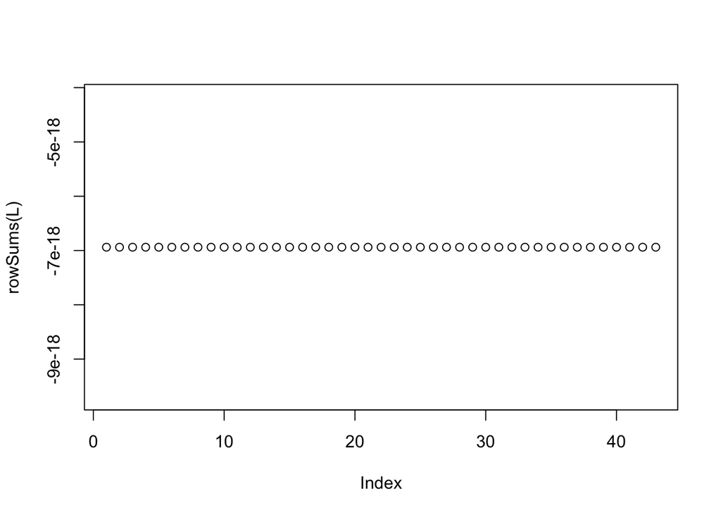

```r
plot(rowSums(L))
```

And that now L%*%mu is just and R-1 vector of 0s:

```r
R=44
L=diag(R)-1/R*as.vector(rep(1,R))%*%t(as.vector(rep(1,R)))


mus=rep(mean(as.numeric(b.train[1,])),44)

as.numeric(round(L%*%mus,digits = 4))
```

```
##  [1] 0 0 0 0 0 0 0 0 0 0 0 0 0 0 0 0 0 0 0 0 0 0 0 0 0 0 0 0 0 0 0 0 0 0 0
## [36] 0 0 0 0 0 0 0 0 0
```

```r
L=L[-44,]
as.numeric(round(L%*%mus,digits = 4))
```

```
##  [1] 0 0 0 0 0 0 0 0 0 0 0 0 0 0 0 0 0 0 0 0 0 0 0 0 0 0 0 0 0 0 0 0 0 0 0
## [36] 0 0 0 0 0 0 0 0
```

Show that this doesn’t change if you change which row of L you are omitting:

```r
rm(L)
rm(b.gp.hat)
R=44
L=diag(R)-1/R*as.vector(rep(1,R))%*%t(as.vector(rep(1,R)))
L=L[-44,]

b.gp.hat=data.frame(t(L%*%t(b.train)))

t44=total.quant.per.snp.no.baseline(j=10,covmat = covmat,b.gp.hat = b.gp.hat,se.gp.hat = se.train,pis = pis,A = A,checkpoint = T,L=L)

rm(L)
rm(b.gp.hat)
##Here we omit the 20^{th} row
R=44
L=diag(R)-1/R*as.vector(rep(1,R))%*%t(as.vector(rep(1,R)))
L=L[-20,]

b.gp.hat=data.frame(t(L%*%t(b.train)))
t20=total.quant.per.snp.no.baseline(j=10,covmat = covmat,b.gp.hat = b.gp.hat,se.gp.hat = se.train,pis = pis,A = A,checkpoint = T,L=L)

all.equal(t20$posterior.means,t44$posterior.means)
```

```
## [1] TRUE
```

```r
all.equal(t20$posterior.nulls,t44$posterior.nulls)
```

```
## [1] TRUE
```

```r
all.equal(t20$posterior.downs,t44$posterior.downs)
```

```
## [1] TRUE
```

```r
all.equal(t20$posterior.ups,t44$posterior.ups)
```

```
## [1] TRUE
```

And as you can see, this transfomred matrix b.gp.hat represents the deviations from the mean across subgroups for n-1 subgroups (not the deviation from the mean of the n-1 subgroups, reassuringly), so the results are robust to which subgroup we omit.

```r
all.equal(as.numeric(b.train[1,]-mean(as.numeric(b.train[1,])))[-20],as.numeric(b.gp.hat[1,]))
```

```
## [1] TRUE
```

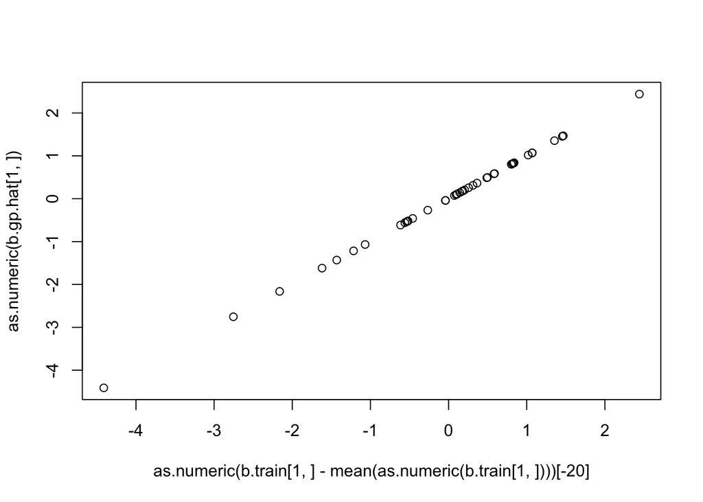

```r
plot(as.numeric(b.train[1,]-mean(as.numeric(b.train[1,])))[-20],as.numeric(b.gp.hat[1,]))
```

So essentially, for every j vector, we have transformed the observed averages to the deviation from observed (noisy averages) across all R subgroups, and then effectively omitted a subgroup. And reassuringly, it doesn’t matter which subgroup we omit when we transform, because L still takes the deviation across all R subgroups (i.e., L is (R-1)xR).

And we can see that it’s deterministic, in that the 0-sum of the R-1 elements will represent the deviation of the omitted element:

```r
as.numeric(b.train[1,]-mean(as.numeric(b.train[1,])))[20]
```

```
## [1] 0.07636031
```

```r
0-sum(b.gp.hat[1,])
```

```
## [1] 0.07636031
```